# FinalEx

```r
#도표
welfare %>%
  filter(!is.na(agegrade) & !is.na(income)) %>%
  group_by(agegrade) %>%
  summarise(income.mean = mean(income), income.sd=sd(income))
```

```
## # A tibble: 3 x 3
##   agegrade income.mean income.sd
## * <chr>          <dbl>     <dbl>
## 1 middle         238.      127.
## 2 old             95.6      72.4
## 3 young          171.       78.1
```

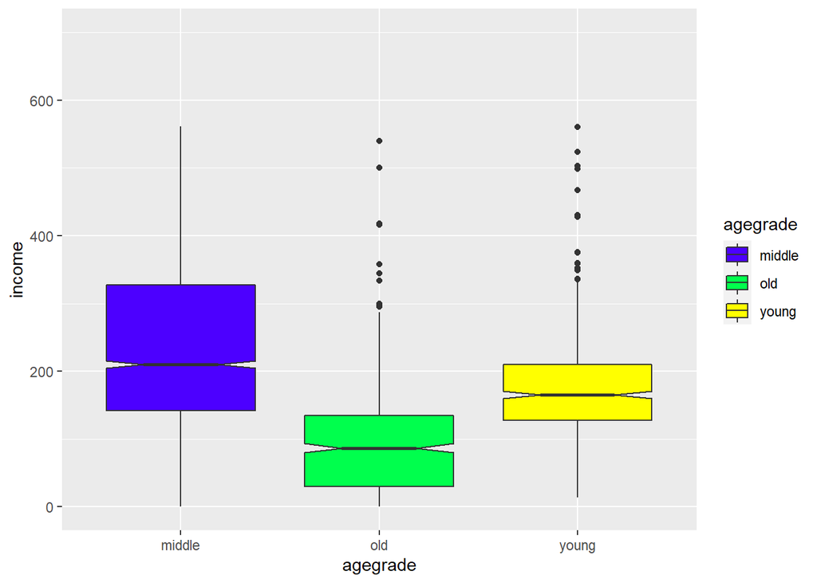

```r
#그래프
ggplot(welfare, aes(x=agegrade, y=income, fill=agegrade)) +
  geom_boxplot(notch = T) +
  scale_fill_manual(values=topo.colors(3)) +
  coord_cartesian(ylim=c(0,700))
```

```r
agegrade_income <- welfare %>%
  group_by(agegrade) %>%
  summarise(income.mean = mean(income, na.rm=T),
            income.sd= sd(income, na.rm=T))
summaryBy(income~agegrade, welfare, FUN=c(mean, sd), na.rm=T)
```

```
##   agegrade income.mean income.sd
## 1   middle    238.2423 126.55679
## 2      old     95.5798  72.35818
## 3    young    170.5965  78.08291
```

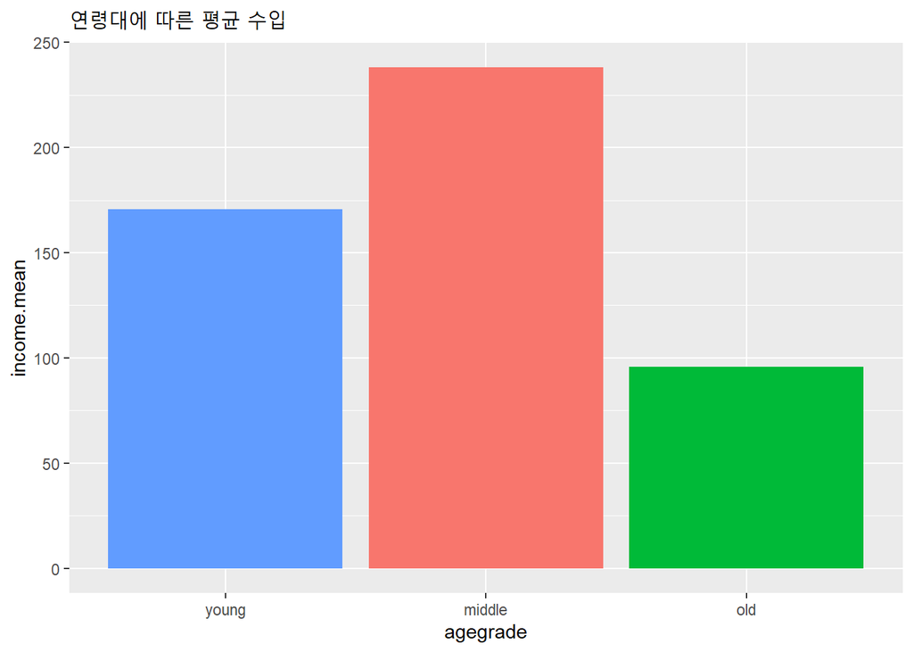

```r
ggplot(agegrade_income, aes(x=agegrade, y=income.mean)) +
  geom_col(aes(fill=agegrade)) +
  scale_x_discrete(limits=c('young','middle','old')) +
  theme(legend.position = "none")+
  labs(title="연령대에 따른 평균 수입")
```

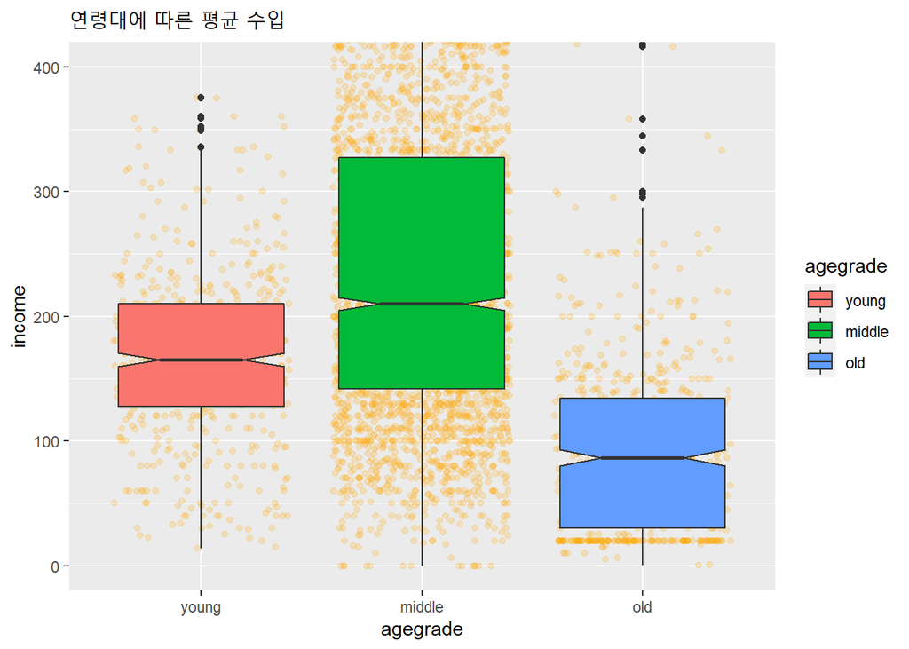

```r
ggplot(welfare, aes(x=agegrade, y=income)) +
  geom_point(position='jitter', col='orange', alpha=0.2)+
  geom_boxplot(aes(fill=agegrade), notch = T) +
  scale_x_discrete(limits=c('young','middle','old')) +
  scale_fill_discrete(limits=c('young','middle','old')) +
  coord_cartesian(ylim=c(0,400))+
  labs(title="연령대에 따른 평균 수입")
```

```r
#통계 분석
temp <- welfare %>%  filter(!is.na(income))
result <- aov(income~agegrade, data=temp)
summary(result)
```

```
##               Df   Sum Sq Mean Sq F value Pr(>F)
## agegrade       2 11455402 5727701     433 <2e-16 ***
## Residuals   4353 57575604   13227
## ---
## Signif. codes:  0 '***' 0.001 '**' 0.01 '*' 0.05 '.' 0.1 ' ' 1
```

```r
(fit <- lm(income~agegrade, data=welfare))
```

```
##
## Call:
## lm(formula = income ~ agegrade, data = welfare)
##
## Coefficients:
##   (Intercept)    agegradeold  agegradeyoung
##        238.24        -142.66         -67.65
```

```r
anova(fit)#다르다
```

```
## Analysis of Variance Table
##
## Response: income
##             Df   Sum Sq Mean Sq F value    Pr(>F)
## agegrade     2 11455402 5727701  433.04 < 2.2e-16 ***
## Residuals 4353 57575604   13227
## ---
## Signif. codes:  0 '***' 0.001 '**' 0.01 '*' 0.05 '.' 0.1 ' ' 1
```

5. 1번 문제의 결과인 data.frame변수를 이용하여 성별에 따른 월급의 차이는 연령대 별로 다른지 분석하시오.

```r
table(is.na(welfare$gender))
```

```
##
## FALSE
## 16664
```

```r
table(is.na(welfare$agegrade))
```

```
##
## FALSE
## 16664
```

```r
table(is.na(welfare$income))
```

```
##
## FALSE  TRUE
##  4356 12308
```

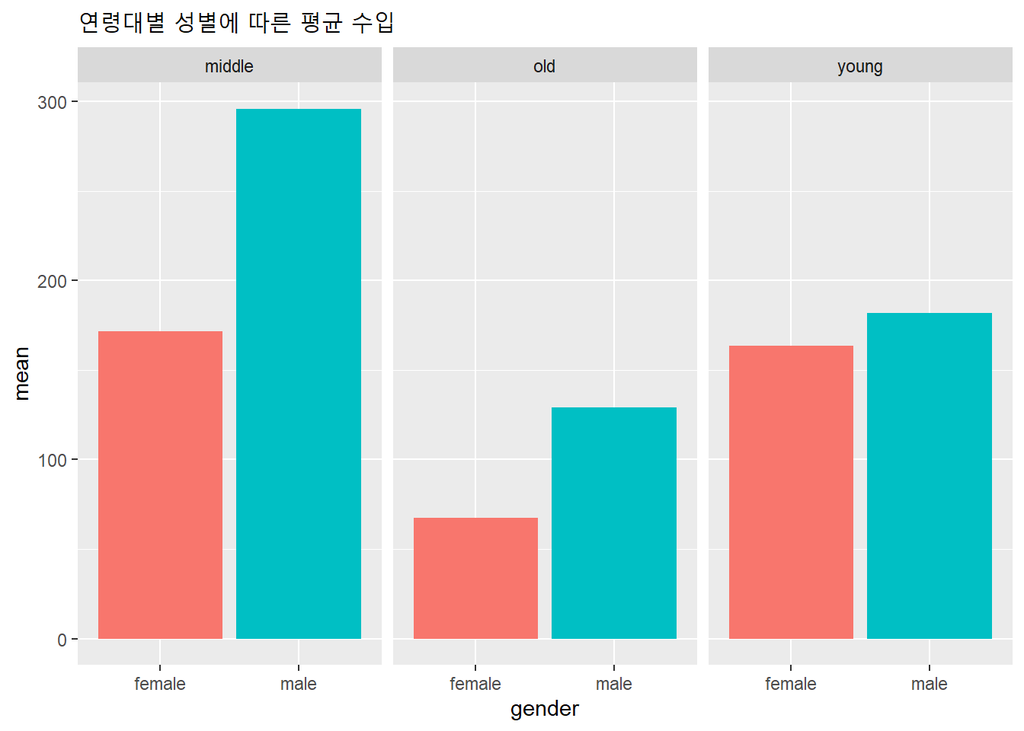

```r
welfare %>%
  filter(!is.na(income)) %>%
  group_by(agegrade, gender) %>%
  summarise(mean=mean(income), sd=sd(income), n()) %>%
  ggplot(aes(x=gender, y=mean))+
  geom_col(aes(fill=gender))+
  facet_wrap(agegrade~.)+
  labs(title="연령대별 성별에 따른 평균 수입")+
  theme(legend.position = "none")
```

6. 1번 문제의 결과인 data.frame변수를 이용하여 나이에 따른 월급 변화를 성별을 분리하여 시각화 하시오.

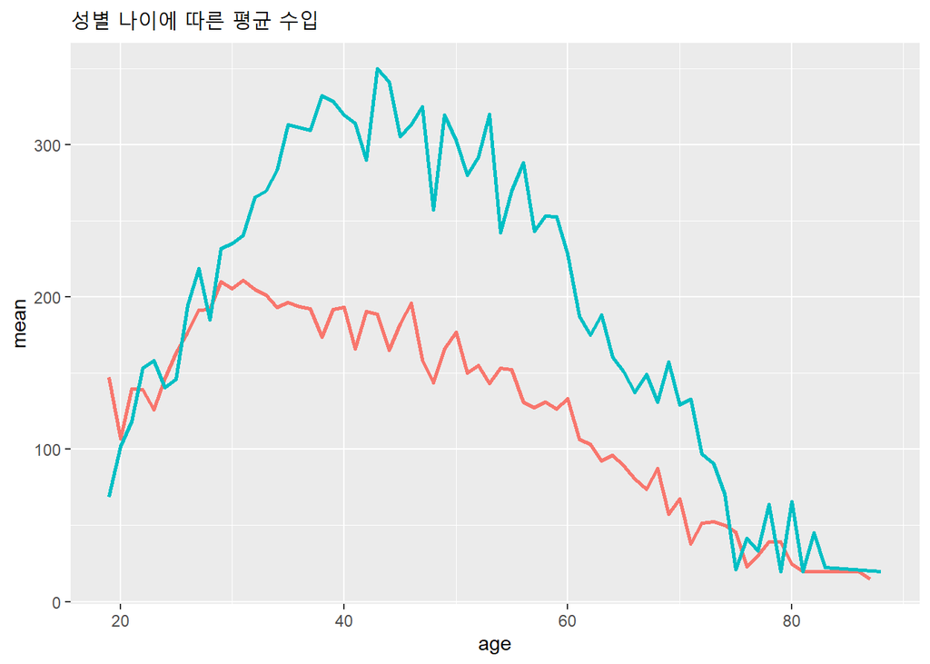

```r
welfare %>%
  filter(!is.na(income)) %>%
  group_by(age, gender) %>%
  summarise(mean=mean(income), sd=sd(income), med = median(income), min=min(income), max=max(income), n()) %>%
  ggplot(aes(x=age, y=mean))+
  geom_line(aes(col=gender), size=1)+
  labs(title="성별 나이에 따른 평균 수입")+
  theme(legend.position = "none")
```

```r
ggsave('outData/FinalEx6.png')
```

7. 1번 문제의 결과인 data.frame변수를 이용하여 직업별 월급의 차이가 나는지 분석하고, 만약 월급의 차이가 나면 어떤 직업이 월급이 가장 많은지 상위 10개 직업군만 시각화하시오.

```r
data <- read_excel("inData/Koweps/Koweps_Codebook_job.xlsx")
data
```

```
## # A tibble: 149 x 2
##    code_job job
##       <dbl> <chr>
##  1      111 의회의원 고위공무원 및 공공단체임원
##  2      112 기업고위임원
##  3      120 행정 및 경영지원 관리자
##  4      131 연구 교육 및 법률 관련 관리자
##  5      132 보험 및 금융 관리자
##  6      133 보건 및 사회복지 관련 관리자
##  7      134 문화 예술 디자인 및 영상 관련 관리자
##  8      135 정보통신관련 관리자
##  9      139 기타 전문서비스 관리자
## 10      141 건설 전기 및 생산 관련 관리자
## # ... with 139 more rows
```

```r
welfare <- left_join(welfare, data, id="code_job")
```

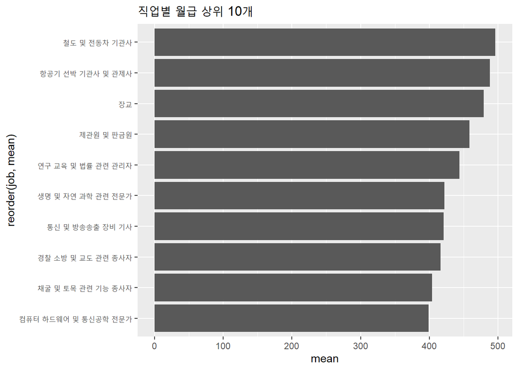

```r
welfare %>%
  filter(!is.na(income)&!is.na(job)) %>%
  group_by(job) %>%
  summarise(mean=mean(income), sd=sd(income), n()) %>%
  arrange(desc(mean)) %>%
  head(10) %>%
  ggplot(aes(x=mean,y=reorder(job, mean)))+
  geom_col()+
  labs(title="직업별 월급 상위 10개")
```

8. 1번 문제의 결과인 data.frame변수를 이용하여 성별로 어떤 직업이 가장 많을지 분석하시오.

```r
welfare %>%
  filter(gender=='male'&!is.na(job)) %>%
  group_by(job) %>%
  summarise(n=n()) %>%
  arrange(-n) %>%
  head(10)
```

```
## # A tibble: 10 x 2
##    job                          n
##    <chr>                    <int>
##  1 작물재배 종사자            640
##  2 자동차 운전원              251
##  3 경영관련 사무원            213
##  4 영업 종사자                141
##  5 매장 판매 종사자           132
##  6 제조관련 단순 종사원       104
##  7 청소원 및 환경 미화원       97
##  8 건설 및 광업 단순 종사원    95
##  9 경비원 및 검표원            95
## 10 행정 사무원                 92
```

```r
welfare %>%
  filter(gender=='female'&!is.na(job)) %>%
  group_by(job) %>%
  summarise(n=n()) %>%
  arrange(-n) %>%
  head(10)
```

```
## # A tibble: 10 x 2
##    job                              n
##    <chr>                        <int>
##  1 작물재배 종사자                680
##  2 청소원 및 환경 미화원          228
##  3 매장 판매 종사자               221
##  4 제조관련 단순 종사원           185
##  5 회계 및 경리 사무원            176
##  6 음식서비스 종사자              149
##  7 주방장 및 조리사               126
##  8 가사 및 육아 도우미            125
##  9 의료 복지 관련 서비스 종사자   121
## 10 음식관련 단순 종사원           104
```

9. 1번 문제의 결과인 data.frame변수를 이용하여 종교 유무에 따른 이혼률을 분석하시오.

```r
table(is.na(welfare$religion))
```

```
##
## FALSE
## 16664
```

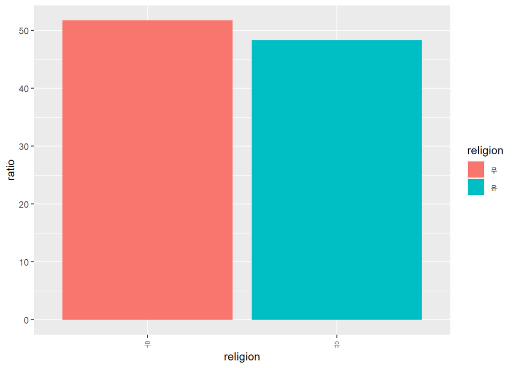

```r
welfare$religion <- ifelse(welfare$religion==1, '유', '무')
welfare$religion <- as.factor(welfare$religion)
welfare %>%
  group_by(religion) %>%
  summarise(ratio=n()/nrow(welfare)*100) %>%
  ggplot(aes(x=religion, y=ratio))+
  geom_col(aes(fill=religion))
```

[figure not shown]

```r
welfare$marriage <- ifelse(welfare$marriage!=1&welfare$marriage!=3, NA, welfare$marriage)
welfare <- welfare %>%
  mutate(marriage_group = ifelse(is.na(marriage), NA, marriage))
welfare$marriage_group[welfare$marriage==1 & !is.na(welfare$marriage_group)] <- '기혼'
welfare$marriage_group[welfare$marriage==3 & !is.na(welfare$marriage_group)] <- '이혼'
welfare %>%
  group_by(religion) %>%
  summarise(ratio = nrow(welfare[!is.na(marriage_group) & marriage_group=='이혼',])/nrow(welfare[!is.na(marriage_group),])*100) %>%
  ggplot(aes(x=religion, y=ratio))+
  geom_col(aes(fill=religion))+
  labs(title="종교 유무에 따른 이혼률")+
  theme(legend.position = "none")
```

10. 1번 문제의 결과인 data.frame변수를 이용하여 지역별 연령대 비율을 분석하시오. 노년층이 많은 지역은 어 디인지 출력하시오.

```r
table(is.na(welfare$religion))
```

```
##
## FALSE
## 16664
```

```r
table(is.na(welfare$agegrade))
```

```
##
## FALSE
## 16664
```

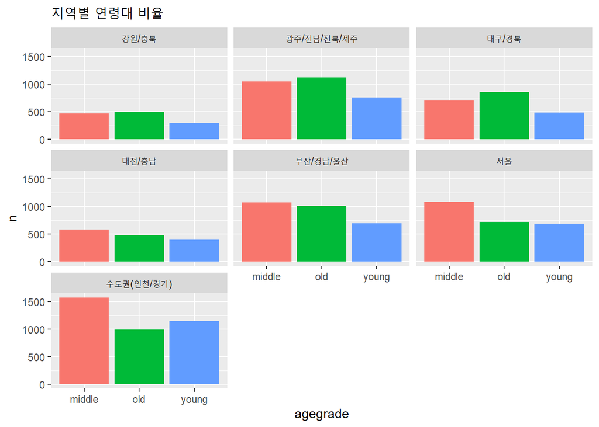

```r
welfare <- welfare %>%
  mutate(region = ifelse(code_region==1, '서울',
                         ifelse(code_region==2, '수도권(인천/경기)',
                                ifelse(code_region==3, '부산/경남/울산',
                                       ifelse(code_region==4, '대구/경북',
                                              ifelse(code_region==5, '대전/충남',
                                                     ifelse(code_region==6, '강원/충북',
                                                            ifelse(code_region==7, '광주/전남/전북/제주', NA))))))))
welfare %>%
  group_by(agegrade, region) %>%
  summarise(n=n()) %>%
  ggplot(aes(x=agegrade, y=n))+
  geom_col(aes(fill=agegrade))+
  facet_wrap(region~.)+
  labs(title="지역별 연령대 비율")+
  theme(legend.position = "none")
```